# Práctica_1

Maria Fernanda Gómez Flores

2026-08-31

# I) Introducción

En esta actividad voy a analizar los rendimientos de Apple (AAPL), NVIDIA (NVDA) y Tesla (TSLA), que son tres activos que cotizan fuera de la Bolsa Mexicana de Valores.

Elegí estas empresas porque son muy conocidas y, aunque las tres están en el mercado de Estados Unidos, sus precios no se comportan igual. Justo por eso me interesa comparar si los mismos hechos estilizados aparecen en las tres o si hay diferencias entre ellas.

Voy a trabajar con precios diarios de los últimos cinco años. Elegí cinco años porque así tengo bastantes datos y también alcanzo a ver periodos más tranquilos y otros con mucha más volatilidad.

Para hacer el análisis voy a usar rendimientos logarítmicos porque me sirven para ver cómo cambia el precio de un día a otro y son los que vimos en clase para trabajar este tipo de series financieras.

## Descarga de precios

Para los tres activos voy a tomar precios diarios desde el 31 de agosto de 2021, para tener un periodo de cinco años.

Escogí este periodo porque me da suficientes observaciones para hacer el análisis y además dentro de esos años hay momentos con comportamientos muy diferentes en el mercado.

Los datos los voy a sacar directamente de Yahoo Finance con la librería `quantmod` de R y para cada activo voy a usar el precio ajustado.

# II) Análisis de los hechos estilizados

```r
library(quantmod)
library(moments)
```

## Activo 1: Apple Inc. (AAPL)

```r
ticker <- "AAPL"

getSymbols(
  ticker,
  src = "yahoo",
  from = "2021-08-31"
)
```

```
## [1] "AAPL"
```

```r
price <- Ad(get(ticker))
head(price)
```

```
##            AAPL.Adjusted
## 2021-08-31      148.0906
## 2021-09-01      148.7538
## 2021-09-02      149.8658
## 2021-09-03      150.4998
## 2021-09-07      152.8309
## 2021-09-08      151.2898
```

### Serie de precios

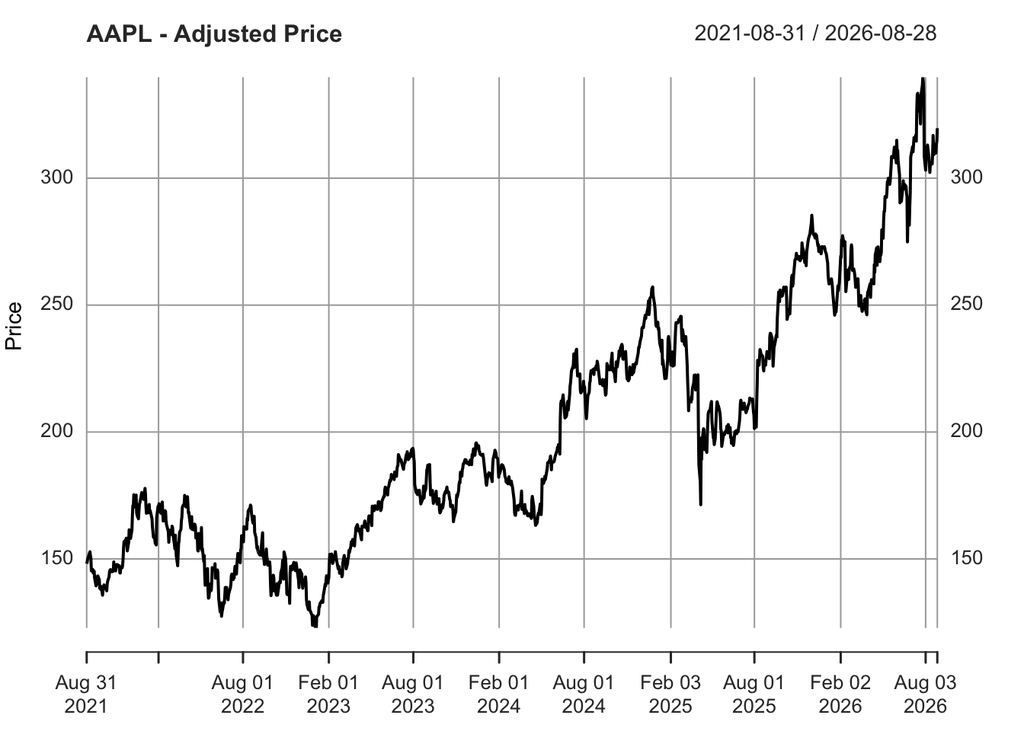

```r
plot(
  price,
  main = paste(ticker, "- Adjusted Price"),
  ylab = "Price",
  xlab = ""
)
```

### Cálculo de rendimientos

Con los precios diarios calculé el rendimiento simple y también el rendimiento logarítmico.

Para los hechos estilizados me voy a quedar con los rendimientos logarítmicos porque me ayudan a ver el cambio del precio de un día a otro y son los que vimos en clase para este tipo de análisis. En el código los calculo usando `type = "log"`.

```r
simple_return <- dailyReturn(
  na.omit(price),
  type = "arithmetic"
)

log_return <- dailyReturn(
  na.omit(price),
  type = "log"
)

head(cbind(simple_return, log_return))
```

```
##            daily.returns daily.returns.1
## 2021-08-31   0.000000000     0.000000000
## 2021-09-01   0.004478703     0.004468704
## 2021-09-02   0.007475023     0.007447224
## 2021-09-03   0.004230368     0.004221445
## 2021-09-07   0.015489266     0.015370532
## 2021-09-08  -0.010083541    -0.010134724
```

### Gráfica de los rendimientos logarítmicos

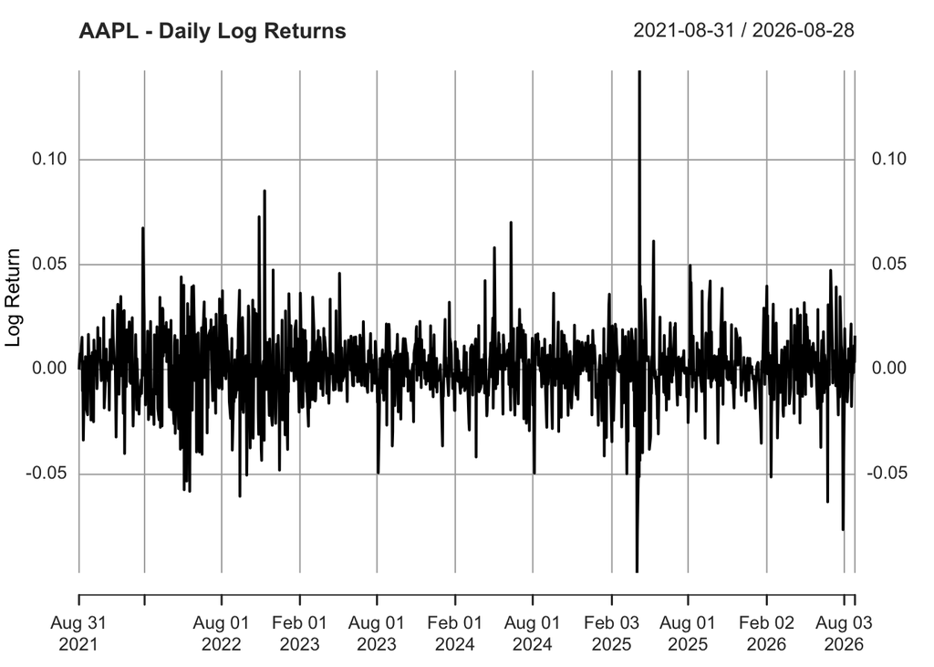

```r
plot(
  log_return,
  main = paste(ticker, "- Daily Log Returns"),
  ylab = "Log Return",
  xlab = ""
)

abline(h = 0, lty = 2)
```

### Hecho I: Dependencia lineal débil de los rendimientos

Este hecho significa que los rendimientos pasados casi no tienen una relación lineal con los rendimientos siguientes. O sea, que saber cómo le fue al activo ayer no necesariamente me sirve para saber cómo le va a ir hoy.

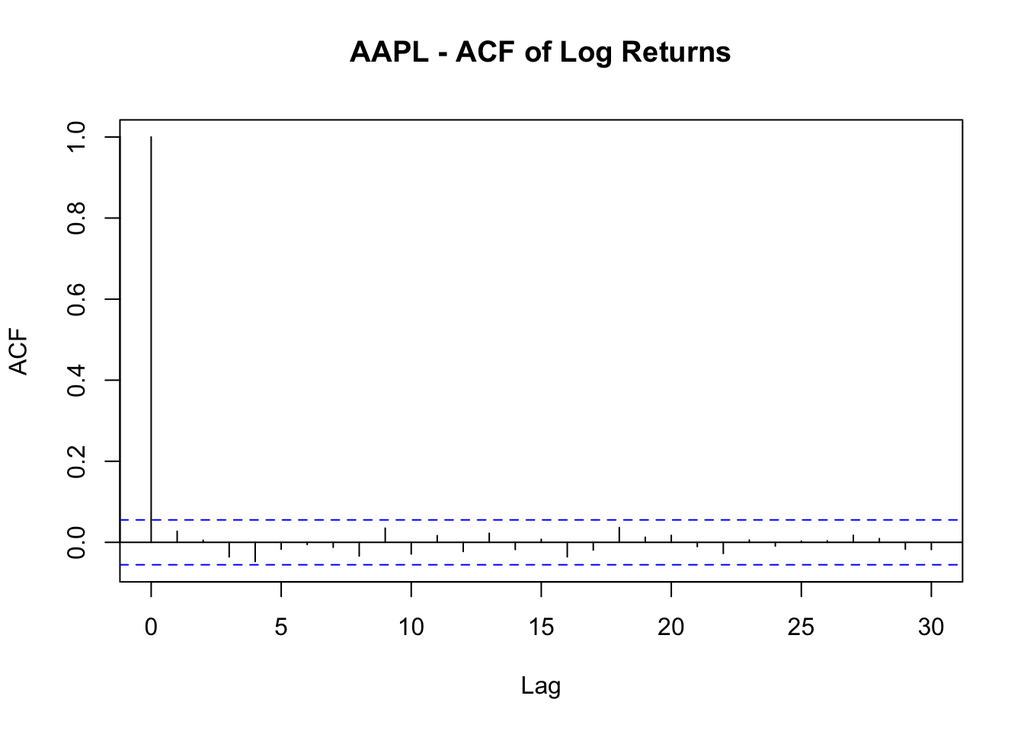

```r
acf(
  na.omit(log_return),
  main = paste(ticker, "- ACF of Log Returns")
)
```

**Interpretación:** En la gráfica de Apple veo que casi todas las autocorrelaciones están muy cerca de cero y dentro de las bandas de confianza. Por eso considero que sí se cumple este hecho, porque los rendimientos anteriores no parecen decirme mucho sobre los siguientes.

### Hecho II: Cluster de volatilidad

Este hecho significa que la volatilidad no aparece de forma totalmente aislada. Hay periodos donde se juntan movimientos grandes y otros donde los rendimientos se mantienen mucho más tranquilos.

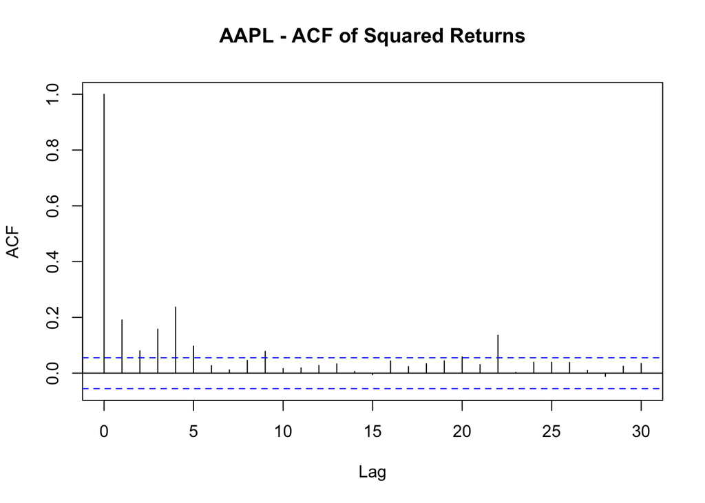

```r
acf(
  na.omit(log_return)^2,
  main = paste(ticker, "- ACF of Squared Returns")
)
```

**Interpretación:** En la ACF de los rendimientos al cuadrado de Apple veo varias barras positivas que pasan las bandas de confianza, sobre todo al inicio. Esto me hace pensar que los movimientos grandes sí tienden a agruparse por periodos, por lo que considero que Apple sí presenta cluster de volatilidad.

### Hecho III: Colas pesadas

Este hecho significa que pueden aparecer rendimientos muy extremos más seguido de lo que esperaría si los datos siguieran una distribución normal.

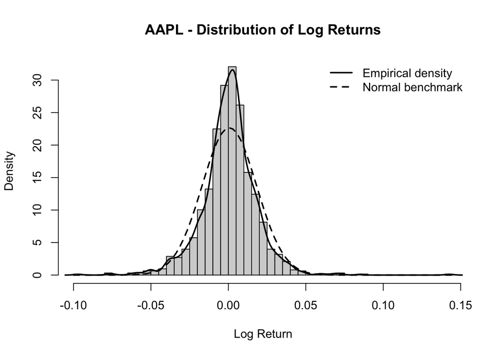

```r
r <- as.numeric(na.omit(log_return))

hist(
  r,
  breaks = 50,
  probability = TRUE,
  main = paste(ticker, "- Distribution of Log Returns"),
  xlab = "Log Return"
)

lines(
  density(r),
  lwd = 2
)

mu_hat <- mean(r)
sigma_hat <- sd(r)

curve(
  dnorm(x, mean = mu_hat, sd = sigma_hat),
  add = TRUE,
  lwd = 2,
  lty = 2
)

legend(
  "topright",
  legend = c("Empirical density", "Normal benchmark"),
  lty = c(1, 2),
  lwd = c(2, 2),
  bty = "n"
)
```

```r
mean_return <- mean(r)
sd_return <- sd(r)
skew_return <- skewness(r)
kurt_return <- kurtosis(r)

excess_kurtosis <- kurt_return - 3

summary_stats <- data.frame(
  Mean = mean_return,
  SD = sd_return,
  Skewness = skew_return,
  Kurtosis = kurt_return,
  Excess_Kurtosis = excess_kurtosis
)

summary_stats
```

```
##           Mean        SD  Skewness Kurtosis Excess_Kurtosis
## 1 0.0006136833 0.0176042 0.1648424 8.721361        5.721361
```

**Interpretación:** En el histograma de Apple veo que la distribución real es más picuda en el centro y también se alarga más en las colas que la normal. Además, la kurtosis me dio 8.72 y el exceso de kurtosis 5.72. Como la kurtosis es mucho mayor a 3, considero que sí hay colas pesadas y que los rendimientos extremos aparecen más de lo que esperaría con una normal.

### Hecho IV: Asimetría

Este hecho se refiere a que la distribución no siempre queda igual de los dos lados. Si la skewness es negativa hay más peso hacia rendimientos negativos extremos y si es positiva hay más peso hacia rendimientos positivos extremos.

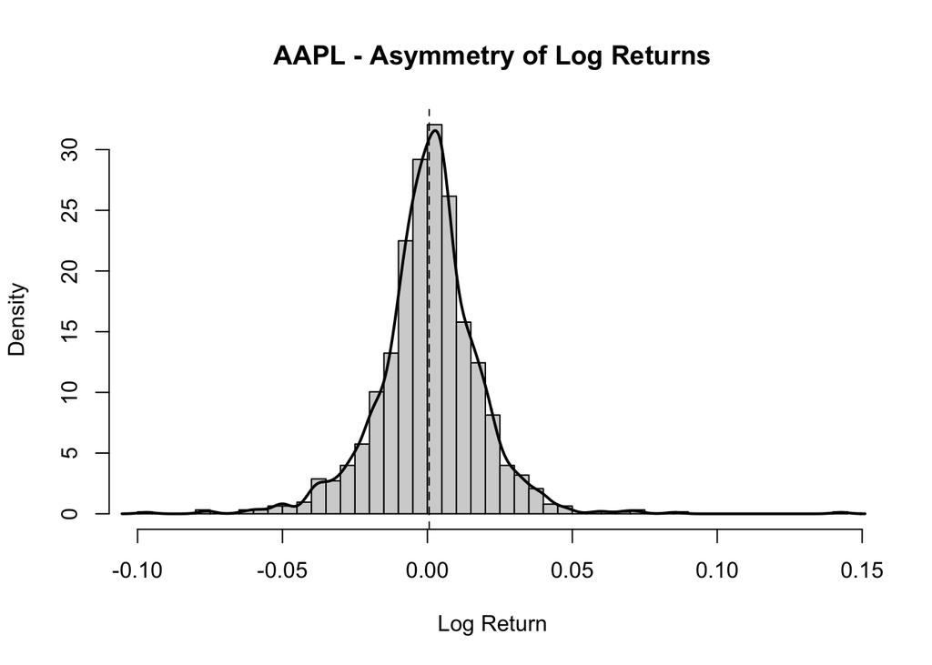

```r
hist(
  r,
  breaks = 50,
  probability = TRUE,
  main = paste(ticker, "- Asymmetry of Log Returns"),
  xlab = "Log Return"
)

lines(density(r), lwd = 2)
abline(v = mean(r), lty = 2)
```

**Interpretación:** La skewness de Apple me dio 0.16. Como es positiva, hay una ligera inclinación hacia rendimientos positivos extremos, pero como el valor sigue estando bastante cerca de cero, no diría que la asimetría sea muy fuerte.

## Activo 2: NVIDIA Corporation (NVDA)

```r
ticker <- "NVDA"

getSymbols(
  ticker,
  src = "yahoo",
  from = "2021-08-31"
)
```

```
## [1] "NVDA"
```

```r
price <- Ad(get(ticker))
head(price)
```

```
##            NVDA.Adjusted
## 2021-08-31      22.31178
## 2021-09-01      22.36759
## 2021-09-02      22.32274
## 2021-09-03      22.76827
## 2021-09-07      22.58787
## 2021-09-08      22.26593
```

### Serie de precios

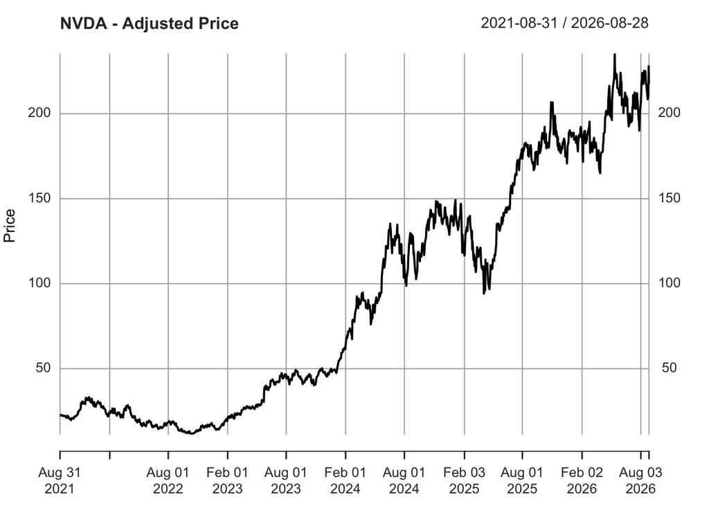

```r
plot(
  price,
  main = paste(ticker, "- Adjusted Price"),
  ylab = "Price",
  xlab = ""
)
```

### Cálculo de rendimientos

Con los precios diarios calculé el rendimiento simple y el rendimiento logarítmico.

Para analizar los hechos estilizados voy a usar los rendimientos logarítmicos porque me ayudan a ver cómo cambia el precio de un día a otro.

```r
simple_return <- dailyReturn(
  na.omit(price),
  type = "arithmetic"
)

log_return <- dailyReturn(
  na.omit(price),
  type = "log"
)

head(cbind(simple_return, log_return))
```

```
##            daily.returns daily.returns.1
## 2021-08-31   0.000000000     0.000000000
## 2021-09-01   0.002501582     0.002498458
## 2021-09-02  -0.002005362    -0.002007375
## 2021-09-03   0.019958913     0.019762345
## 2021-09-07  -0.007923678    -0.007955237
## 2021-09-08  -0.014252593    -0.014355137
```

### Gráfica de los rendimientos logarítmicos

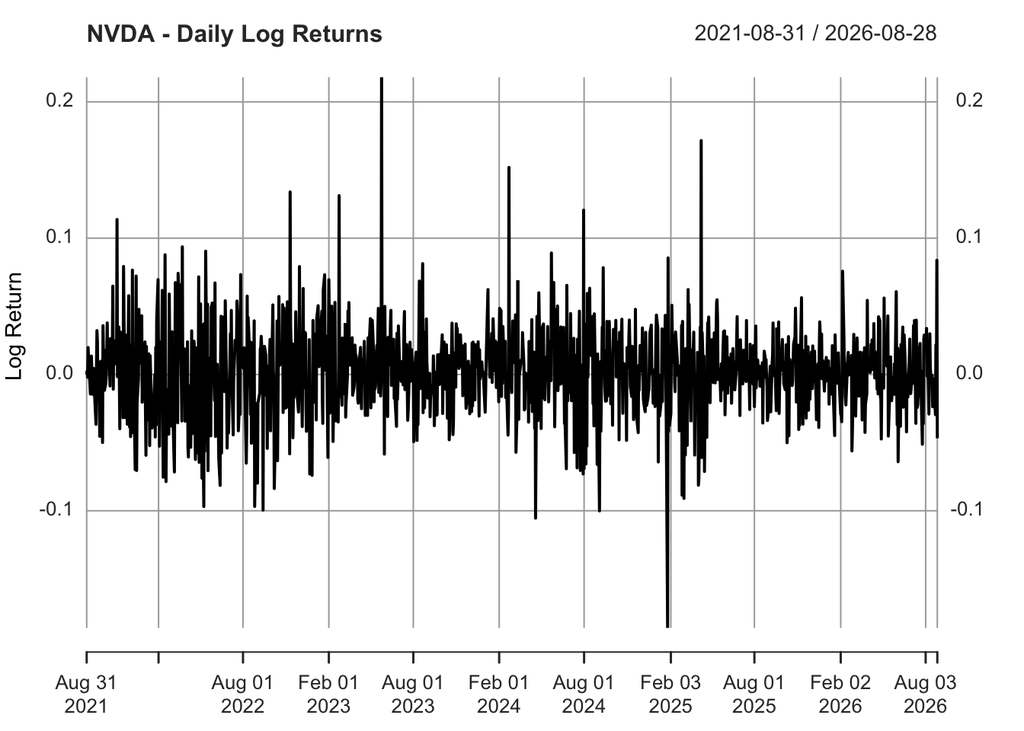

```r
plot(
  log_return,
  main = paste(ticker, "- Daily Log Returns"),
  ylab = "Log Return",
  xlab = ""
)

abline(h = 0, lty = 2)
```

### Hecho I: Dependencia lineal débil de los rendimientos

Este hecho significa que los rendimientos de días anteriores tienen poca relación lineal con los rendimientos futuros.

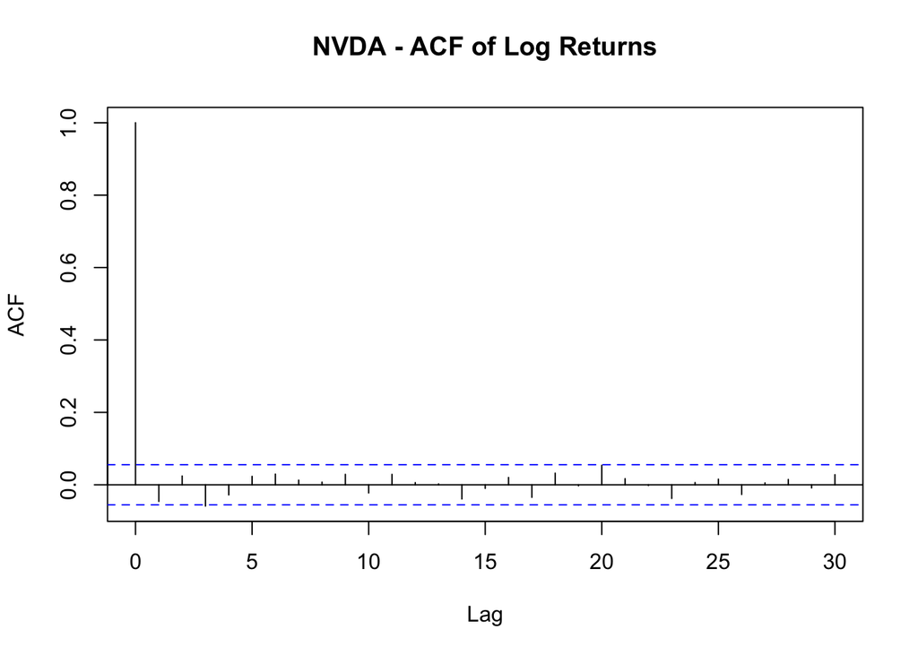

```r
acf(
  na.omit(log_return),
  main = paste(ticker, "- ACF of Log Returns")
)
```

**Interpretación:** En NVIDIA pasa algo parecido a Apple: casi todas las barras de la ACF están cerca de cero y dentro de las bandas. Por eso considero que también se cumple la dependencia lineal débil.

### Hecho II: Cluster de volatilidad

Este hecho significa que los periodos de mucha y poca volatilidad tienden a aparecer agrupados y no completamente al azar.

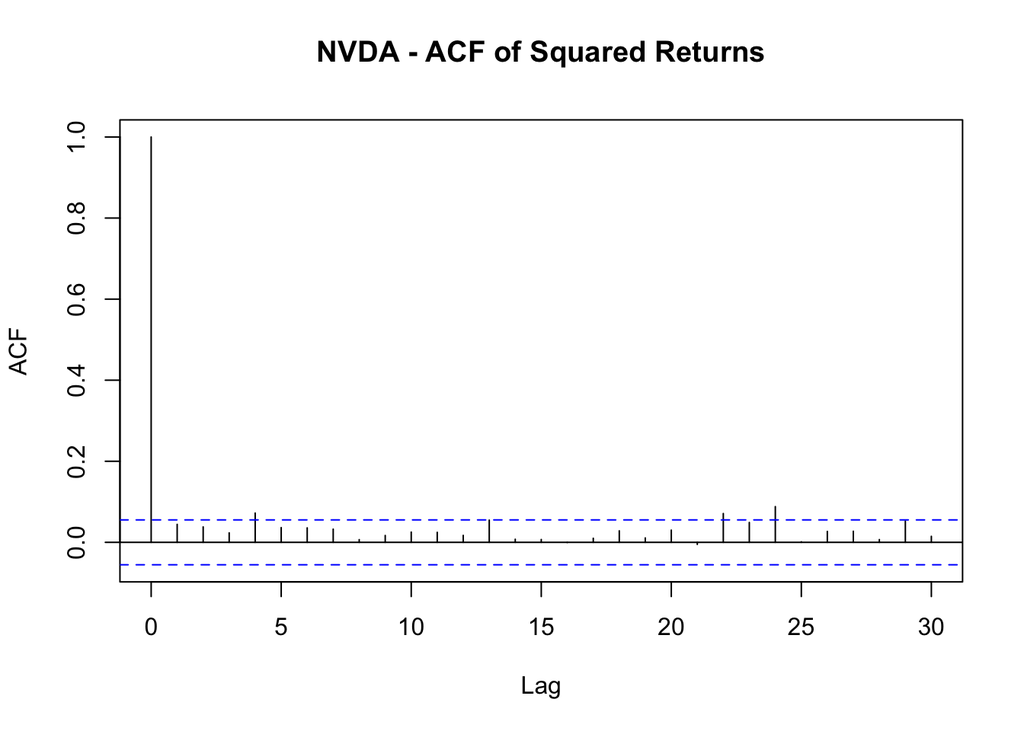

```r
acf(
  na.omit(log_return)^2,
  main = paste(ticker, "- ACF of Squared Returns")
)
```

**Interpretación:** En la ACF de los rendimientos al cuadrado de NVIDIA también aparecen algunas barras positivas fuera de las bandas. Entonces sí veo evidencia de cluster de volatilidad, aunque visualmente se ve menos fuerte que en Apple.

### Hecho III: Colas pesadas

Este hecho significa que pueden aparecer rendimientos extremos más seguido de lo que esperaría con una distribución normal.

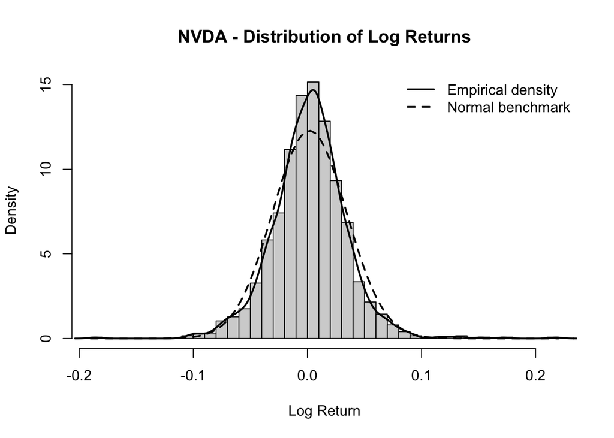

```r
r <- as.numeric(na.omit(log_return))

hist(
  r,
  breaks = 50,
  probability = TRUE,
  main = paste(ticker, "- Distribution of Log Returns"),
  xlab = "Log Return"
)

lines(
  density(r),
  lwd = 2
)

mu_hat <- mean(r)
sigma_hat <- sd(r)

curve(
  dnorm(x, mean = mu_hat, sd = sigma_hat),
  add = TRUE,
  lwd = 2,
  lty = 2
)

legend(
  "topright",
  legend = c("Empirical density", "Normal benchmark"),
  lty = c(1, 2),
  lwd = c(2, 2),
  bty = "n"
)
```

```r
mean_return <- mean(r)
sd_return <- sd(r)
skew_return <- skewness(r)
kurt_return <- kurtosis(r)

excess_kurtosis <- kurt_return - 3

summary_stats <- data.frame(
  Mean = mean_return,
  SD = sd_return,
  Skewness = skew_return,
  Kurtosis = kurt_return,
  Excess_Kurtosis = excess_kurtosis
)

summary_stats
```

```
##         Mean         SD  Skewness Kurtosis Excess_Kurtosis
## 1 0.00181604 0.03249703 0.2604999 6.715088        3.715088
```

**Interpretación:** En el histograma de NVIDIA también se ve que la distribución real es más concentrada en el centro y se aleja de la normal en las colas. La kurtosis me dio 6.72 y el exceso de kurtosis 3.72. Como sigue siendo mayor a 3, considero que NVIDIA también tiene colas pesadas.

### Hecho IV: Asimetría

Este hecho se refiere a que la distribución puede estar un poco más cargada hacia rendimientos positivos o hacia rendimientos negativos.

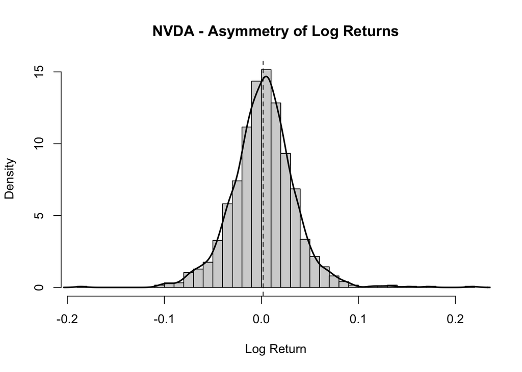

```r
hist(
  r,
  breaks = 50,
  probability = TRUE,
  main = paste(ticker, "- Asymmetry of Log Returns"),
  xlab = "Log Return"
)

lines(density(r), lwd = 2)
abline(v = mean(r), lty = 2)
```

**Interpretación:** La skewness de NVIDIA me dio 0.26. Es positiva y un poco mayor que la de Apple, entonces sí hay una ligera inclinación hacia rendimientos positivos extremos, aunque tampoco es una asimetría demasiado fuerte.

## Activo 3: Tesla Inc. (TSLA)

```r
ticker <- "TSLA"

getSymbols(
  ticker,
  src = "yahoo",
  from = "2021-08-31"
)
```

```
## [1] "TSLA"
```

```r
price <- Ad(get(ticker))
head(price)
```

```
##            TSLA.Adjusted
## 2021-08-31      245.2400
## 2021-09-01      244.6967
## 2021-09-02      244.1300
## 2021-09-03      244.5233
## 2021-09-07      250.9733
## 2021-09-08      251.2900
```

### Serie de precios

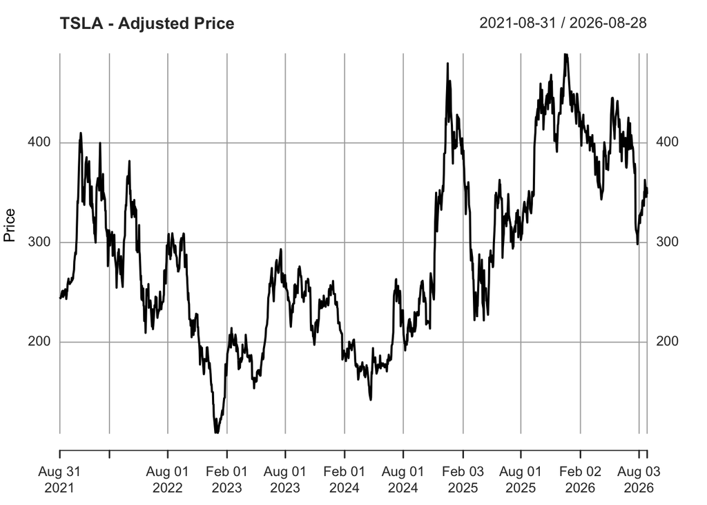

```r
plot(
  price,
  main = paste(ticker, "- Adjusted Price"),
  ylab = "Price",
  xlab = ""
)
```

### Cálculo de rendimientos

Con los precios diarios calculé el rendimiento simple y el rendimiento logarítmico.

Para analizar los hechos estilizados voy a usar los rendimientos logarítmicos porque me ayudan a ver cómo cambia el precio de un día a otro.

```r
simple_return <- dailyReturn(
  na.omit(price),
  type = "arithmetic"
)

log_return <- dailyReturn(
  na.omit(price),
  type = "log"
)

head(cbind(simple_return, log_return))
```

```
##            daily.returns daily.returns.1
## 2021-08-31   0.000000000     0.000000000
## 2021-09-01  -0.002215523    -0.002217981
## 2021-09-02  -0.002315788    -0.002318474
## 2021-09-03   0.001611133     0.001609836
## 2021-09-07   0.026377839     0.026035943
## 2021-09-08   0.001261750     0.001260955
```

### Gráfica de los rendimientos logarítmicos

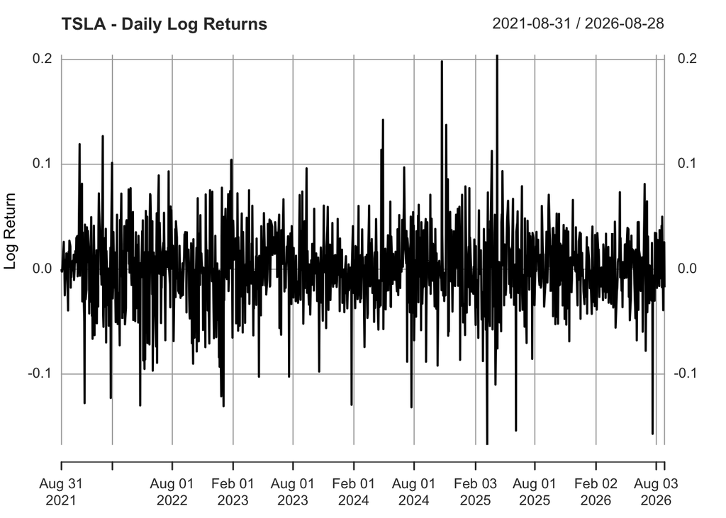

```r
plot(
  log_return,
  main = paste(ticker, "- Daily Log Returns"),
  ylab = "Log Return",
  xlab = ""
)

abline(h = 0, lty = 2)
```

### Hecho I: Dependencia lineal débil de los rendimientos

Este hecho significa que los rendimientos pasados tienen poca relación lineal con los que vienen después.

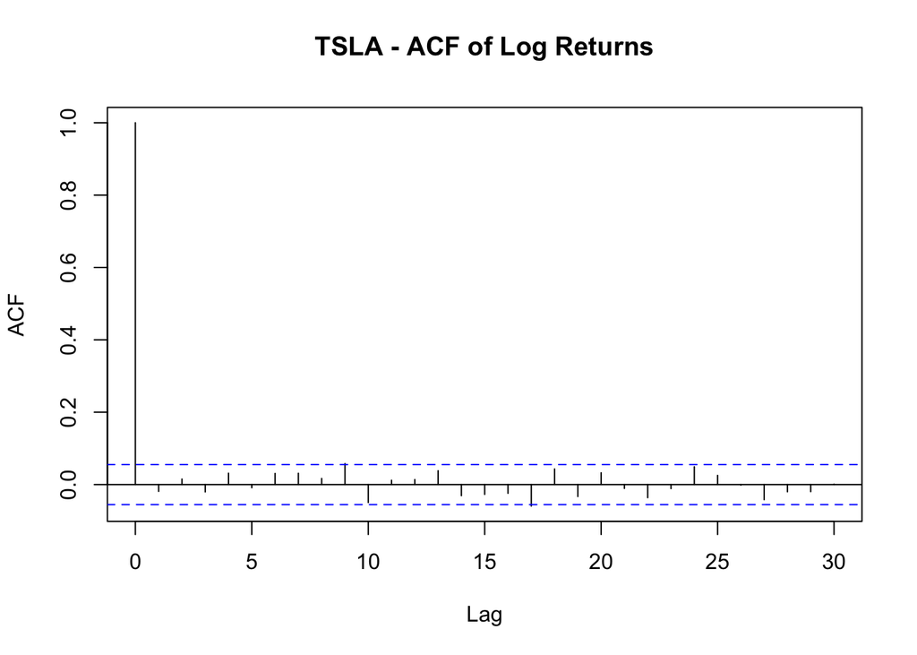

```r
acf(
  na.omit(log_return),
  main = paste(ticker, "- ACF of Log Returns")
)
```

**Interpretación:** En Tesla también veo que la mayoría de las autocorrelaciones están cerca de cero y dentro de las bandas de confianza. Entonces considero que también se cumple la dependencia lineal débil.

### Hecho II: Cluster de volatilidad

Este hecho significa que los periodos de mucha y poca volatilidad tienden a aparecer agrupados y no completamente al azar.

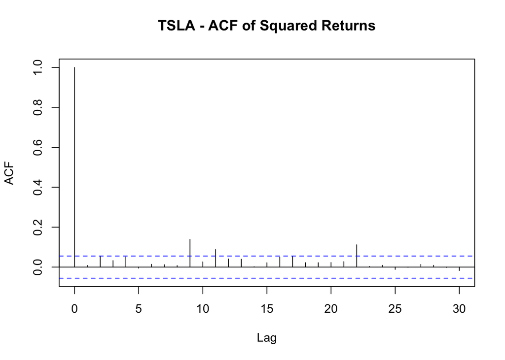

```r
acf(
  na.omit(log_return)^2,
  main = paste(ticker, "- ACF of Squared Returns")
)
```

**Interpretación:** En la ACF de los rendimientos al cuadrado de Tesla aparecen varias barras positivas que pasan las bandas. Por eso considero que también hay cluster de volatilidad, ya que los movimientos grandes sí parecen agruparse por periodos.

### Hecho III: Colas pesadas

Este hecho significa que puede haber rendimientos extremos con más frecuencia de la que esperaría si los datos fueran normales.

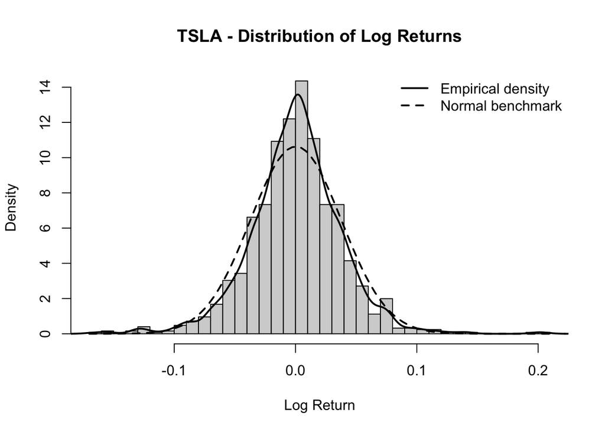

```r
r <- as.numeric(na.omit(log_return))

hist(
  r,
  breaks = 50,
  probability = TRUE,
  main = paste(ticker, "- Distribution of Log Returns"),
  xlab = "Log Return"
)

lines(
  density(r),
  lwd = 2
)

mu_hat <- mean(r)
sigma_hat <- sd(r)

curve(
  dnorm(x, mean = mu_hat, sd = sigma_hat),
  add = TRUE,
  lwd = 2,
  lty = 2
)

legend(
  "topright",
  legend = c("Empirical density", "Normal benchmark"),
  lty = c(1, 2),
  lwd = c(2, 2),
  bty = "n"
)
```

```r
mean_return <- mean(r)
sd_return <- sd(r)
skew_return <- skewness(r)
kurt_return <- kurtosis(r)

excess_kurtosis <- kurt_return - 3

summary_stats <- data.frame(
  Mean = mean_return,
  SD = sd_return,
  Skewness = skew_return,
  Kurtosis = kurt_return,
  Excess_Kurtosis = excess_kurtosis
)

summary_stats
```

```
##           Mean         SD    Skewness Kurtosis Excess_Kurtosis
## 1 0.0002807958 0.03753383 -0.01484405 5.635929        2.635929
```

**Interpretación:** En Tesla también se ve que la distribución real es más picuda que la normal y tiene más peso en las colas. La kurtosis me dio 5.64 y el exceso de kurtosis 2.64, así que también considero que hay colas pesadas.

### Hecho IV: Asimetría

Este hecho se refiere a que la distribución puede estar un poco más cargada hacia rendimientos positivos o hacia rendimientos negativos.

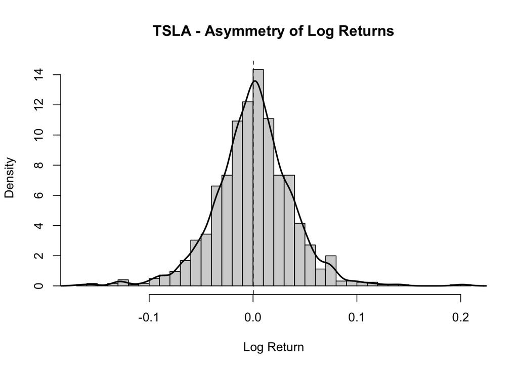

```r
hist(
  r,
  breaks = 50,
  probability = TRUE,
  main = paste(ticker, "- Asymmetry of Log Returns"),
  xlab = "Log Return"
)

lines(density(r), lwd = 2)
abline(v = mean(r), lty = 2)
```

**Interpretación:** La skewness de Tesla me dio -0.01, que está prácticamente en cero. Aunque es ligeramente negativa, para mí la distribución es casi simétrica y no veo una asimetría importante.

# III) Auditoria con IA

Para revisar si mis interpretaciones sí tenían sentido utilicé ChatGPT.

## Prompt utilizado

**“Con base en estos resultados:

AAPL: En la ACF de los rendimientos veo que casi todas las autocorrelaciones están cerca de cero, por lo que considero que presenta dependencia lineal débil. En la ACF de los rendimientos al cuadrado aparecen varias barras positivas fuera de las bandas, por lo que veo evidencia de cluster de volatilidad. La kurtosis fue de 8.72 y el exceso de kurtosis de 5.72, así que considero que presenta colas pesadas. La skewness fue de 0.16, por lo que tiene una ligera asimetría positiva.

NVDA: La ACF de los rendimientos también muestra valores cercanos a cero, por lo que considero que presenta dependencia lineal débil. En los rendimientos al cuadrado aparecen algunas autocorrelaciones positivas fuera de las bandas, así que también veo cluster de volatilidad. La kurtosis fue de 6.72 y el exceso de kurtosis de 3.72, por lo que presenta colas pesadas. La skewness fue de 0.26, así que tiene una ligera asimetría positiva.

TSLA: La mayoría de las autocorrelaciones de los rendimientos están cerca de cero, por lo que considero que presenta dependencia lineal débil. En la ACF de los rendimientos al cuadrado aparecen varias barras positivas fuera de las bandas, así que también veo cluster de volatilidad. La kurtosis fue de 5.64 y el exceso de kurtosis de 2.64, por lo que presenta colas pesadas. La skewness fue de -0.01, entonces su distribución es prácticamente simétrica.

Revisa si mi análisis sobre los hechos estilizados está justificado. Señala posibles fallas metodológicas o interpretativas.”**

## Respuesta de la IA

En general, el análisis está bien justificado y las herramientas utilizadas son adecuadas para revisar los cuatro hechos estilizados.

Para la dependencia lineal débil, usar la ACF de los rendimientos es correcto. En los tres activos la mayoría de las autocorrelaciones se encuentran cerca de cero y dentro de las bandas de confianza, por lo que sí hay evidencia de poca dependencia lineal. Sin embargo, conviene decir que esto no significa que los rendimientos sean completamente independientes, solo que no presentan una relación lineal fuerte.

Para el cluster de volatilidad, la ACF de los rendimientos al cuadrado también es una herramienta adecuada. En los tres activos aparecen autocorrelaciones positivas que superan las bandas de confianza, lo que indica que periodos de alta volatilidad tienden a agruparse. Aun así, esta gráfica funciona como evidencia del fenómeno, pero no sustituye un modelo formal de volatilidad como un GARCH.

En cuanto a las colas pesadas, la comparación entre la densidad empírica y la normal, junto con la kurtosis, sí permite justificar la presencia de este hecho estilizado. Apple tiene una kurtosis de 8.72, NVIDIA de 6.72 y Tesla de 5.64, todas mayores a 3, por lo que los tres activos muestran más peso en las colas que una distribución normal. Apple es el activo que presenta la evidencia más fuerte de colas pesadas entre los tres.

Para la asimetría, la interpretación también es correcta. Apple y NVIDIA presentan skewness positiva, aunque relativamente baja, mientras que Tesla tiene una skewness muy cercana a cero. En este caso es importante no afirmar que la asimetría se presenta con fuerza en los tres activos, ya que en Tesla prácticamente no aparece.

Como posible mejora metodológica, se podría complementar el análisis de colas pesadas con un QQ-plot y el análisis de autocorrelación con alguna prueba estadística como Ljung-Box. Sin embargo, con las herramientas utilizadas en la actividad sí existe evidencia suficiente para realizar un análisis descriptivo de los cuatro hechos estilizados.

## Cambios a partir de la auditoria

Después de leer la respuesta de la IA no cambiaría los cálculos ni las gráficas porque sí me sirven para revisar los cuatro hechos.

Lo que sí cambiaría es la forma de escribir algunas conclusiones. Por ejemplo, en la dependencia lineal débil no diría que los rendimientos son totalmente independientes, sino solamente que tienen poca relación lineal. También tomaría la ACF de los rendimientos al cuadrado como evidencia del cluster de volatilidad, no como una prueba definitiva. Y en la asimetría dejaría claro que no tiene que aparecer forzosamente en todos los activos, como pasó con Tesla que quedó casi simétrica.

# IV) Conclusiones

Después de comparar Apple, NVIDIA y Tesla me di cuenta de que los tres sí comparten varios de los hechos estilizados que vimos en clase.  
En los tres la dependencia lineal de los rendimientos es baja porque casi todas las autocorrelaciones están cerca de cero.  
También veo cluster de volatilidad en los tres, ya que en los rendimientos al cuadrado sí aparecen varias autocorrelaciones positivas significativas.  
Los tres presentan colas pesadas, pero no con la misma intensidad.  
Apple fue el que tuvo la kurtosis más alta con 8.72, después NVIDIA con 6.72 y Tesla con 5.64.  
Para mí esto significa que Apple fue el que mostró una mayor presencia de movimientos extremos dentro de este periodo.  
En la asimetría también hubo diferencias.  
Apple y NVIDIA tuvieron una ligera asimetría positiva, siendo NVIDIA la más alta con 0.26 y Apple con 0.16.  
Tesla fue diferente porque su skewness fue de -0.01, entonces su distribución quedó prácticamente simétrica.  
Aunque las tres empresas están en el mismo mercado, sus rendimientos claramente no se comportan exactamente igual.  
Esto importa para medir riesgo porque no tendría sentido asumir que todos los activos siguen una normal o que todos tienen el mismo nivel y tipo de riesgo.  
También me deja claro que para medir riesgo sí hay que tomar en cuenta los movimientos extremos y que la volatilidad cambia con el tiempo.